# Systeme de notation interne

sbaa syrine

12/13/2022

```r
library(skimr)
library(readxl)
library(gmodels)
```

```r
library(ggplot2)
BD<- read_excel("C:/Users/pc/Downloads/Base de données - SNI (1).xlsx")
skim(BD)
```

Data summary

| Name | BD |
| --- | --- |
| Number of rows | 1521 |
| Number of columns | 40 |
| _______________________ |  |
| Column type frequency: |  |
| character | 13 |
| numeric | 25 |
| POSIXct | 2 |
| ________________________ |  |
| Group variables | None |

**Variable type: character**

| skim_variable | n_missing | complete_rate | min | max | empty | n_unique | whitespace |
| --- | --- | --- | --- | --- | --- | --- | --- |
| NUMTIERS_ANNEE | 0 | 1 | 18 | 18 | 0 | 1521 | 0 |
| EXPERIENCE_MANAGEMENT_MOYENNE_DIRIGEANT | 0 | 1 | 13 | 18 | 0 | 4 | 0 |
| DIVERSITE_CLIENTS | 0 | 1 | 13 | 92 | 0 | 7 | 0 |
| DIVERSITE_FOURNISSEURS | 0 | 1 | 13 | 21 | 0 | 6 | 0 |
| IMPACT_SOCIAUX_ENVIRONNEMENTAL | 0 | 1 | 12 | 67 | 0 | 6 | 0 |
| NIVEAU_COMPETITIVITE | 0 | 1 | 22 | 52 | 0 | 5 | 0 |
| QUALITE_INFORMATION_FINANCIERE | 0 | 1 | 40 | 61 | 0 | 4 | 0 |
| REPUTATION | 0 | 1 | 5 | 10 | 0 | 5 | 0 |
| STRUCTUREDUMANAGEMENT | 0 | 1 | 13 | 21 | 0 | 4 | 0 |
| SUPPORT | 0 | 1 | 13 | 35 | 0 | 5 | 0 |
| POSITIONNEMENTMARCHE | 0 | 1 | 6 | 40 | 0 | 4 | 0 |
| Categorie_juridique | 0 | 1 | 2 | 22 | 0 | 3 | 0 |
| Secteurs | 0 | 1 | 15 | 67 | 0 | 17 | 0 |

**Variable type: numeric**

| skim_variable | n_missing | complete_rate | mean | sd | p0 | p25 | p50 | p75 | p100 | hist |
| --- | --- | --- | --- | --- | --- | --- | --- | --- | --- | --- |
| numtiers | 0 | 1 | 5.200003e+12 | 2.789631e+06 | 5.200000e+12 | 5.200001e+12 | 5.200001e+12 | 5.200002e+12 | 5.200009e+12 | ▇▁▁▁▂ |
| Annee | 0 | 1 | 2.016720e+03 | 1.340000e+00 | 2.015000e+03 | 2.016000e+03 | 2.017000e+03 | 2.018000e+03 | 2.019000e+03 | ▇▇▇▆▅ |
| defaut | 0 | 1 | 3.000000e-02 | 1.800000e-01 | 0.000000e+00 | 0.000000e+00 | 0.000000e+00 | 0.000000e+00 | 1.000000e+00 | ▇▁▁▁▁ |
| CHIFFRE_AFFAIRES | 0 | 1 | 8.836712e+08 | 2.260292e+09 | 2.407834e+05 | 2.201000e+08 | 3.666245e+08 | 7.300641e+08 | 4.654680e+10 | ▇▁▁▁▁ |
| EXCEDENT_BRUT_EXPLOITATION | 0 | 1 | 1.113634e+11 | 4.338997e+12 | -7.244920e+08 | 9.256980e+06 | 2.337180e+07 | 6.484448e+07 | 1.692210e+14 | ▇▁▁▁▁ |
| RESULTAT_EXPlOITATION | 0 | 1 | 7.084423e+07 | 3.374614e+08 | -9.228820e+08 | 6.046446e+06 | 1.626471e+07 | 4.753765e+07 | 7.383194e+09 | ▇▁▁▁▁ |
| RESULTAT_NET | 0 | 1 | 4.466026e+07 | 2.689441e+08 | -1.365167e+09 | 1.626665e+06 | 6.890254e+06 | 2.619013e+07 | 6.191285e+09 | ▇▁▁▁▁ |
| FINANCEMENT_PERMANENT | 0 | 1 | 8.179797e+08 | 5.511221e+09 | -2.181978e+08 | 5.395758e+07 | 1.243755e+08 | 3.521020e+08 | 1.324880e+11 | ▇▁▁▁▁ |
| FONDS_DE_ROULEMENT | 0 | 1 | 7.360449e+08 | 5.156720e+09 | -8.024065e+08 | 4.796964e+07 | 1.061373e+08 | 3.201599e+08 | 1.310860e+11 | ▇▁▁▁▁ |
| BESOIN_FONDS_ROULEMENT | 0 | 1 | 8.221021e+08 | 5.118160e+09 | -5.311209e+08 | 7.470461e+07 | 1.705486e+08 | 4.277569e+08 | 1.283850e+11 | ▇▁▁▁▁ |
| CAPITAUX_PROPRES | 0 | 1 | 5.072981e+08 | 3.172077e+09 | -3.459610e+08 | 4.274029e+07 | 9.691615e+07 | 2.537554e+08 | 6.715046e+10 | ▇▁▁▁▁ |
| TRESORIE_NETTE | 0 | 1 | -8.567422e+07 | 3.284837e+08 | -6.022071e+09 | -1.057937e+08 | -3.556344e+07 | 2.236801e+06 | 2.701014e+09 | ▁▁▁▇▁ |
| TOTAL_BILAN | 0 | 1 | 1.104408e+09 | 4.313678e+09 | 0.000000e+00 | 1.965210e+08 | 3.610497e+08 | 7.727153e+08 | 9.132607e+10 | ▇▁▁▁▁ |
| DETTE_FINANCIERE | 0 | 1 | 2.831542e+08 | 2.311711e+09 | 0.000000e+00 | 0.000000e+00 | 8.186202e+06 | 5.065129e+07 | 5.871914e+10 | ▇▁▁▁▁ |
| ACTIF_CIRCULANT | 0 | 1 | 7.381823e+08 | 2.704953e+09 | 0.000000e+00 | 1.515939e+08 | 2.693334e+08 | 5.981656e+08 | 6.557718e+10 | ▇▁▁▁▁ |
| PASSIF_CIRCULANT | 0 | 1 | 4.626149e+08 | 1.379349e+09 | 0.000000e+00 | 7.979395e+07 | 1.621355e+08 | 3.277756e+08 | 2.519313e+10 | ▇▁▁▁▁ |
| TOTAL_ACTIF | 0 | 1 | 1.412505e+09 | 6.622539e+09 | 0.000000e+00 | 2.112174e+08 | 3.926067e+08 | 8.910426e+08 | 1.561210e+11 | ▇▁▁▁▁ |
| TOTAL_PASSIF | 0 | 1 | 1.415091e+09 | 6.624351e+09 | 0.000000e+00 | 2.099258e+08 | 3.924325e+08 | 8.882205e+08 | 1.561210e+11 | ▇▁▁▁▁ |
| DELAI_REGLEMENT_CLIENTS | 0 | 1 | 3.116200e+02 | 4.705690e+03 | 0.000000e+00 | 5.790000e+01 | 1.063000e+02 | 1.814300e+02 | 1.809681e+05 | ▇▁▁▁▁ |
| DELAI_REGLEMENT_FOURNISSEURS | 0 | 1 | 9.640700e+02 | 1.447067e+04 | 0.000000e+00 | 8.146000e+01 | 1.339600e+02 | 2.064200e+02 | 4.938076e+05 | ▇▁▁▁▁ |
| AUTO_FINANCEMENT | 0 | 1 | 4.932546e+07 | 2.907861e+08 | -8.732279e+08 | 2.364414e+06 | 9.076155e+06 | 2.902258e+07 | 7.236063e+09 | ▇▁▁▁▁ |
| FRAIS_FINANCIERS | 0 | 1 | 2.849152e+07 | 1.747951e+08 | 0.000000e+00 | 2.854053e+06 | 6.881266e+06 | 1.574645e+07 | 4.688320e+09 | ▇▁▁▁▁ |
| STOCK | 0 | 1 | 2.138622e+08 | 7.241134e+08 | 0.000000e+00 | 2.540362e+07 | 6.403557e+07 | 1.641099e+08 | 1.011758e+10 | ▇▁▁▁▁ |
| Cote en bourse | 0 | 1 | 4.000000e-02 | 1.900000e-01 | 0.000000e+00 | 0.000000e+00 | 0.000000e+00 | 0.000000e+00 | 1.000000e+00 | ▇▁▁▁▁ |
| Appartenance a un groupe | 0 | 1 | 6.200000e-01 | 4.900000e-01 | 0.000000e+00 | 0.000000e+00 | 1.000000e+00 | 1.000000e+00 | 1.000000e+00 | ▅▁▁▁▇ |

**Variable type: POSIXct**

| skim_variable | n_missing | complete_rate | min | max | median | n_unique |
| --- | --- | --- | --- | --- | --- | --- |
| DATE_DE_CREATION_TIERS | 0 | 1 | 1956-04-03 | 2018-07-04 | 2003-03-07 | 450 |
| DATE_DE_CREATION_ENTREP | 0 | 1 | 1919-02-08 | 2022-04-11 | 1996-06-12 | 465 |

##1 / Description de la base##

```r
str(BD)
```

```
## tibble [1,521 x 40] (S3: tbl_df/tbl/data.frame)
##  $ numtiers                               : num [1:1521] 5.2e+12 5.2e+12 5.2e+12 5.2e+12 5.2e+12 ...
##  $ Annee                                  : num [1:1521] 2015 2016 2015 2017 2015 ...
##  $ NUMTIERS_ANNEE                         : chr [1:1521] "5200000007513_2015" "5200000007513_2016" "5200000007934_2015" "5200000007934_2017" ...
##  $ defaut                                 : num [1:1521] 0 0 0 0 0 0 0 0 0 0 ...
##  $ DATE_DE_CREATION_TIERS                 : POSIXct[1:1521], format: "2008-01-02" "2008-01-02" ...
##  $ DATE_DE_CREATION_ENTREP                : POSIXct[1:1521], format: "1982-01-05" "1982-01-05" ...
##  $ CHIFFRE_AFFAIRES                       : num [1:1521] 2.36e+08 2.58e+08 2.02e+08 2.11e+08 1.72e+08 ...
##  $ EXCEDENT_BRUT_EXPLOITATION             : num [1:1521] 8258202 4107269 5028465 13076488 16142630 ...
##  $ RESULTAT_EXPlOITATION                  : num [1:1521] 7120503 2031312 3602226 12514234 12544852 ...
##  $ RESULTAT_NET                           : num [1:1521] -14040380 2312467 -413273 7501947 1401029 ...
##  $ FINANCEMENT_PERMANENT                  : num [1:1521] 98670395 98615614 25786354 43636341 55186478 ...
##  $ FONDS_DE_ROULEMENT                     : num [1:1521] 81519577 95726091 25292672 43556341 55087778 ...
##  $ BESOIN_FONDS_ROULEMENT                 : num [1:1521] 1.10e+08 1.25e+08 1.69e+07 3.86e+07 1.03e+08 ...
##  $ CAPITAUX_PROPRES                       : num [1:1521] 94487686 96800153 25786354 43636341 51002844 ...
```

[output cut: 26 more lines]

```r
summary(BD)
```

```
##     numtiers           Annee      NUMTIERS_ANNEE         defaut
##  Min.   :5.2e+12   Min.   :2015   Length:1521        Min.   :0.00000
##  1st Qu.:5.2e+12   1st Qu.:2016   Class :character   1st Qu.:0.00000
##  Median :5.2e+12   Median :2017   Mode  :character   Median :0.00000
##  Mean   :5.2e+12   Mean   :2017                      Mean   :0.03485
##  3rd Qu.:5.2e+12   3rd Qu.:2018                      3rd Qu.:0.00000
##  Max.   :5.2e+12   Max.   :2019                      Max.   :1.00000
##  DATE_DE_CREATION_TIERS        DATE_DE_CREATION_ENTREP
##  Min.   :1956-04-03 00:00:00   Min.   :1919-02-08 00:00:00
##  1st Qu.:1992-05-06 00:00:00   1st Qu.:1979-10-29 00:00:00
##  Median :2003-03-07 00:00:00   Median :1996-06-12 00:00:00
##  Mean   :1998-12-19 20:37:23   Mean   :1990-10-01 12:46:51
##  3rd Qu.:2010-04-20 00:00:00   3rd Qu.:2004-09-13 00:00:00
##  Max.   :2018-07-04 00:00:00   Max.   :2022-04-11 00:00:00
##  CHIFFRE_AFFAIRES    EXCEDENT_BRUT_EXPLOITATION RESULTAT_EXPlOITATION
##  Min.   :2.408e+05   Min.   :-7.245e+08         Min.   :-922882043
##  1st Qu.:2.201e+08   1st Qu.: 9.257e+06         1st Qu.:   6046446
##  Median :3.666e+08   Median : 2.337e+07         Median :  16264708
##  Mean   :8.837e+08   Mean   : 1.114e+11         Mean   :  70844231
##  3rd Qu.:7.301e+08   3rd Qu.: 6.484e+07         3rd Qu.:  47537652
##  Max.   :4.655e+10   Max.   : 1.692e+14         Max.   :7383193832
##   RESULTAT_NET        FINANCEMENT_PERMANENT FONDS_DE_ROULEMENT
##  Min.   :-1.365e+09   Min.   :-2.182e+08    Min.   :-8.024e+08
##  1st Qu.: 1.627e+06   1st Qu.: 5.396e+07    1st Qu.: 4.797e+07
##  Median : 6.890e+06   Median : 1.244e+08    Median : 1.061e+08
##  Mean   : 4.466e+07   Mean   : 8.180e+08    Mean   : 7.360e+08
##  3rd Qu.: 2.619e+07   3rd Qu.: 3.521e+08    3rd Qu.: 3.202e+08
##  Max.   : 6.191e+09   Max.   : 1.325e+11    Max.   : 1.311e+11
##  BESOIN_FONDS_ROULEMENT CAPITAUX_PROPRES     TRESORIE_NETTE
##  Min.   :-5.311e+08     Min.   :-3.460e+08   Min.   :-6.022e+09
##  1st Qu.: 7.470e+07     1st Qu.: 4.274e+07   1st Qu.:-1.058e+08
##  Median : 1.705e+08     Median : 9.692e+07   Median :-3.556e+07
##  Mean   : 8.221e+08     Mean   : 5.073e+08   Mean   :-8.567e+07
##  3rd Qu.: 4.278e+08     3rd Qu.: 2.538e+08   3rd Qu.: 2.237e+06
##  Max.   : 1.284e+11     Max.   : 6.715e+10   Max.   : 2.701e+09
##   TOTAL_BILAN        DETTE_FINANCIERE    ACTIF_CIRCULANT
##  Min.   :0.000e+00   Min.   :0.000e+00   Min.   :0.000e+00
##  1st Qu.:1.965e+08   1st Qu.:0.000e+00   1st Qu.:1.516e+08
##  Median :3.610e+08   Median :8.186e+06   Median :2.693e+08
##  Mean   :1.104e+09   Mean   :2.832e+08   Mean   :7.382e+08
```

[output cut: 43 more lines]

```
##
##    SUPPORT          POSITIONNEMENTMARCHE Categorie_juridique Cote en bourse
##  Length:1521        Length:1521          Length:1521         Min.   :0.00000
##  Class :character   Class :character     Class :character    1st Qu.:0.00000
##  Mode  :character   Mode  :character     Mode  :character    Median :0.00000
##                                                              Mean   :0.03813
##                                                              3rd Qu.:0.00000
##                                                              Max.   :1.00000
##  Appartenance a un groupe   Secteurs
##  Min.   :0.0000           Length:1521
##  1st Qu.:0.0000           Class :character
##  Median :1.0000           Mode  :character
##  Mean   :0.6213
##  3rd Qu.:1.0000
##  Max.   :1.0000
```

On a une base de données de 40 variables et 1521 lignes.

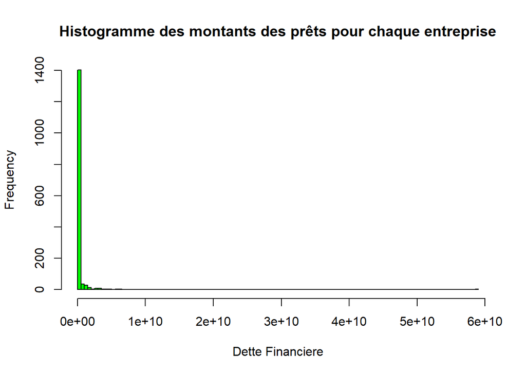

```r
histogram <- hist(BD$DETTE_FINANCIERE, breaks = 200, xlab = "Dette Financiere",
               main = "Histogramme des montants des prêts pour chaque entreprise",col = "green")
```

```r
CrossTable(BD$DETTE_FINANCIERE)
```

```
##
##
##    Cell Contents
## |-------------------------|
## |                       N |
## |         N / Table Total |
## |-------------------------|
##
##
## Total Observations in Table:  1521
##
##
##             |           0 |     6466.59 |        8195 |       17746 |    43650.99 |
##             |-------------|-------------|-------------|-------------|-------------|
##             |         563 |           1 |           1 |           1 |           1 |
##             |       0.370 |       0.001 |       0.001 |       0.001 |       0.001 |
##             |-------------|-------------|-------------|-------------|-------------|
##
##
##             |       46000 |       50000 |    53842.87 |    90932.09 |   101926.36 |
##             |-------------|-------------|-------------|-------------|-------------|
##             |           3 |           1 |           1 |           1 |           1 |
##             |       0.002 |       0.001 |       0.001 |       0.001 |       0.001 |
##             |-------------|-------------|-------------|-------------|-------------|
##
##
##             |      140320 |   145779.94 |   160711.43 |   172802.34 |      187500 |
##             |-------------|-------------|-------------|-------------|-------------|
##             |           3 |           1 |           1 |           1 |           1 |
##             |       0.002 |       0.001 |       0.001 |       0.001 |       0.001 |
##             |-------------|-------------|-------------|-------------|-------------|
##
##
##             |   189909.96 |   192156.37 |   216605.58 |      225000 |   243452.45 |
##             |-------------|-------------|-------------|-------------|-------------|
##             |           1 |           1 |           1 |           1 |           1 |
##             |       0.001 |       0.001 |       0.001 |       0.001 |       0.001 |
##             |-------------|-------------|-------------|-------------|-------------|
##
##
```

[output cut: 1219 more lines]

```
##             |-------------|-------------|-------------|-------------|-------------|
##             |           1 |           1 |           1 |           1 |           1 |
##             |       0.001 |       0.001 |       0.001 |       0.001 |       0.001 |
##             |-------------|-------------|-------------|-------------|-------------|
##
##
##             | 58719141010 |
##             |-------------|
##             |           1 |
##             |       0.001 |
##             |-------------|
##
##
##
##
```

```r
Cross<-CrossTable(BD$REPUTATION, BD$defaut, prop.r = TRUE,
           prop.c = FALSE, prop.t = FALSE, prop.chisq = FALSE)
```

```
##
##
##    Cell Contents
## |-------------------------|
## |                       N |
## |           N / Row Total |
## |-------------------------|
##
##
## Total Observations in Table:  1521
##
##
##               | BD$defaut
## BD$REPUTATION |         0 |         1 | Row Total |
## --------------|-----------|-----------|-----------|
##         Bonne |       392 |        15 |       407 |
##               |     0.963 |     0.037 |     0.268 |
## --------------|-----------|-----------|-----------|
##      Mauvaise |         3 |         1 |         4 |
##               |     0.750 |     0.250 |     0.003 |
## --------------|-----------|-----------|-----------|
##       Moyenne |        25 |         1 |        26 |
##               |     0.962 |     0.038 |     0.017 |
## --------------|-----------|-----------|-----------|
##    Tres bonne |      1048 |        35 |      1083 |
##               |     0.968 |     0.032 |     0.712 |
## --------------|-----------|-----------|-----------|
##    Très bonne |         0 |         1 |         1 |
##               |     0.000 |     1.000 |     0.001 |
## --------------|-----------|-----------|-----------|
##  Column Total |      1468 |        53 |      1521 |
## --------------|-----------|-----------|-----------|
##
##
```

Nous pouvons en conclure que la proportion de défaut augmente avec la détérioration de la réputation (de mauvaise à très bonne), comme nous nous y attendions.

[figure not shown]

```r
plot(Cross$prop.tbl,col = c("aquamarine1","chartreuse2"),main = "Proportions of Default/Non-Default wrt Ownership"
     ,xlab = "Reputation de l'entreprise",ylab = "1 - Defaut    0 - Pas de defaut")
```

```r
summary(BD$EXPERIENCE_MANAGEMENT_MOYENNE_DIRIGEANT)
```

```
##    Length     Class      Mode
##      1521 character character
```

```r
summary(BD$DIVERSITE_CLIENTS)
```

```
##    Length     Class      Mode
##      1521 character character
```

```r
summary(BD$DIVERSITE_FOURNISSEURS)
```

```
##    Length     Class      Mode
##      1521 character character
```

```r
BD$EXPERIENCE_MANAGEMENT_MOYENNE_DIRIGEANT[BD$EXPERIENCE_MANAGEMENT_MOYENNE_DIRIGEANT == "Modalite vide" ] <- NA
BD$DIVERSITE_CLIENTS[BD$DIVERSITE_CLIENTS == "Modalite vide" ] <- NA
BD$DIVERSITE_FOURNISSEURS[BD$DIVERSITE_FOURNISSEURS == "Modalite vide" ] <- NA
BD$SUPPORT[BD$SUPPORT == "Modalite vide" ] <- NA
BD
```

```
## # A tibble: 1,521 x 40
##     numtiers Annee NUMTIERS_ANNEE defaut DATE_DE_CREATION_T~ DATE_DE_CREATION_E~
##        <dbl> <dbl> <chr>           <dbl> <dttm>              <dttm>
##  1   5.20e12  2015 5200000007513~      0 2008-01-02 00:00:00 1982-01-05 00:00:00
##  2   5.20e12  2016 5200000007513~      0 2008-01-02 00:00:00 1982-01-05 00:00:00
##  3   5.20e12  2015 5200000007934~      0 1988-05-31 00:00:00 1953-08-05 00:00:00
##  4   5.20e12  2017 5200000007934~      0 1988-05-31 00:00:00 1953-08-05 00:00:00
##  5   5.20e12  2015 5200000008051~      0 1998-10-02 00:00:00 1995-05-22 00:00:00
##  6   5.20e12  2016 5200000008051~      0 1998-10-02 00:00:00 1995-05-22 00:00:00
##  7   5.20e12  2017 5200000008051~      0 1998-10-02 00:00:00 1995-05-22 00:00:00
##  8   5.20e12  2015 5200000008052~      0 1998-10-02 00:00:00 1989-02-14 00:00:00
##  9   5.20e12  2016 5200000008052~      0 1998-10-02 00:00:00 1989-02-14 00:00:00
## 10   5.20e12  2017 5200000008052~      0 1998-10-02 00:00:00 1989-02-14 00:00:00
## # ... with 1,511 more rows, and 34 more variables: CHIFFRE_AFFAIRES <dbl>,
## #   EXCEDENT_BRUT_EXPLOITATION <dbl>, RESULTAT_EXPlOITATION <dbl>,
## #   RESULTAT_NET <dbl>, FINANCEMENT_PERMANENT <dbl>, FONDS_DE_ROULEMENT <dbl>,
## #   BESOIN_FONDS_ROULEMENT <dbl>, CAPITAUX_PROPRES <dbl>, TRESORIE_NETTE <dbl>,
## #   TOTAL_BILAN <dbl>, DETTE_FINANCIERE <dbl>, ACTIF_CIRCULANT <dbl>,
## #   PASSIF_CIRCULANT <dbl>, TOTAL_ACTIF <dbl>, TOTAL_PASSIF <dbl>,
## #   DELAI_REGLEMENT_CLIENTS <dbl>, DELAI_REGLEMENT_FOURNISSEURS <dbl>, ...
```

On va mettre les entreprises en categorie selon leur experience manageriale.

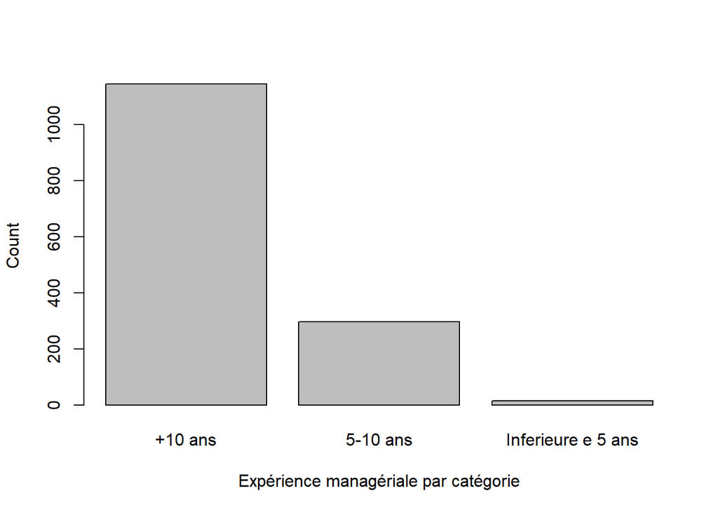

```r
BD$EXPERIENCE_MANAGEMENT_MOYENNE_DIRIGEANT[BD$EXPERIENCE_MANAGEMENT_MOYENNE_DIRIGEANT == "Entre 5 et 10 ans" ] <- "5-10 ans"
BD$EXPERIENCE_MANAGEMENT_MOYENNE_DIRIGEANT[BD$EXPERIENCE_MANAGEMENT_MOYENNE_DIRIGEANT == "Plus de 10 ans" ] <- "+10 ans"
BD$EXPERIENCE_MANAGEMENT_MOYENNE_DIRIGEANT <- as.factor(BD$EXPERIENCE_MANAGEMENT_MOYENNE_DIRIGEANT) #

plot(BD$EXPERIENCE_MANAGEMENT_MOYENNE_DIRIGEANT,xlab = "Expérience managériale par catégorie",ylab = "Count") #
```

```r
BD$AGE = round(as.numeric(difftime(Sys.Date(),BD$DATE_DE_CREATION_ENTREP, units = "weeks"))/52.25)
BD
```

```
## # A tibble: 1,521 x 41
##     numtiers Annee NUMTIERS_ANNEE defaut DATE_DE_CREATION_T~ DATE_DE_CREATION_E~
##        <dbl> <dbl> <chr>           <dbl> <dttm>              <dttm>
##  1   5.20e12  2015 5200000007513~      0 2008-01-02 00:00:00 1982-01-05 00:00:00
##  2   5.20e12  2016 5200000007513~      0 2008-01-02 00:00:00 1982-01-05 00:00:00
##  3   5.20e12  2015 5200000007934~      0 1988-05-31 00:00:00 1953-08-05 00:00:00
##  4   5.20e12  2017 5200000007934~      0 1988-05-31 00:00:00 1953-08-05 00:00:00
##  5   5.20e12  2015 5200000008051~      0 1998-10-02 00:00:00 1995-05-22 00:00:00
##  6   5.20e12  2016 5200000008051~      0 1998-10-02 00:00:00 1995-05-22 00:00:00
##  7   5.20e12  2017 5200000008051~      0 1998-10-02 00:00:00 1995-05-22 00:00:00
##  8   5.20e12  2015 5200000008052~      0 1998-10-02 00:00:00 1989-02-14 00:00:00
##  9   5.20e12  2016 5200000008052~      0 1998-10-02 00:00:00 1989-02-14 00:00:00
## 10   5.20e12  2017 5200000008052~      0 1998-10-02 00:00:00 1989-02-14 00:00:00
## # ... with 1,511 more rows, and 35 more variables: CHIFFRE_AFFAIRES <dbl>,
## #   EXCEDENT_BRUT_EXPLOITATION <dbl>, RESULTAT_EXPlOITATION <dbl>,
## #   RESULTAT_NET <dbl>, FINANCEMENT_PERMANENT <dbl>, FONDS_DE_ROULEMENT <dbl>,
## #   BESOIN_FONDS_ROULEMENT <dbl>, CAPITAUX_PROPRES <dbl>, TRESORIE_NETTE <dbl>,
## #   TOTAL_BILAN <dbl>, DETTE_FINANCIERE <dbl>, ACTIF_CIRCULANT <dbl>,
## #   PASSIF_CIRCULANT <dbl>, TOTAL_ACTIF <dbl>, TOTAL_PASSIF <dbl>,
## #   DELAI_REGLEMENT_CLIENTS <dbl>, DELAI_REGLEMENT_FOURNISSEURS <dbl>, ...
```

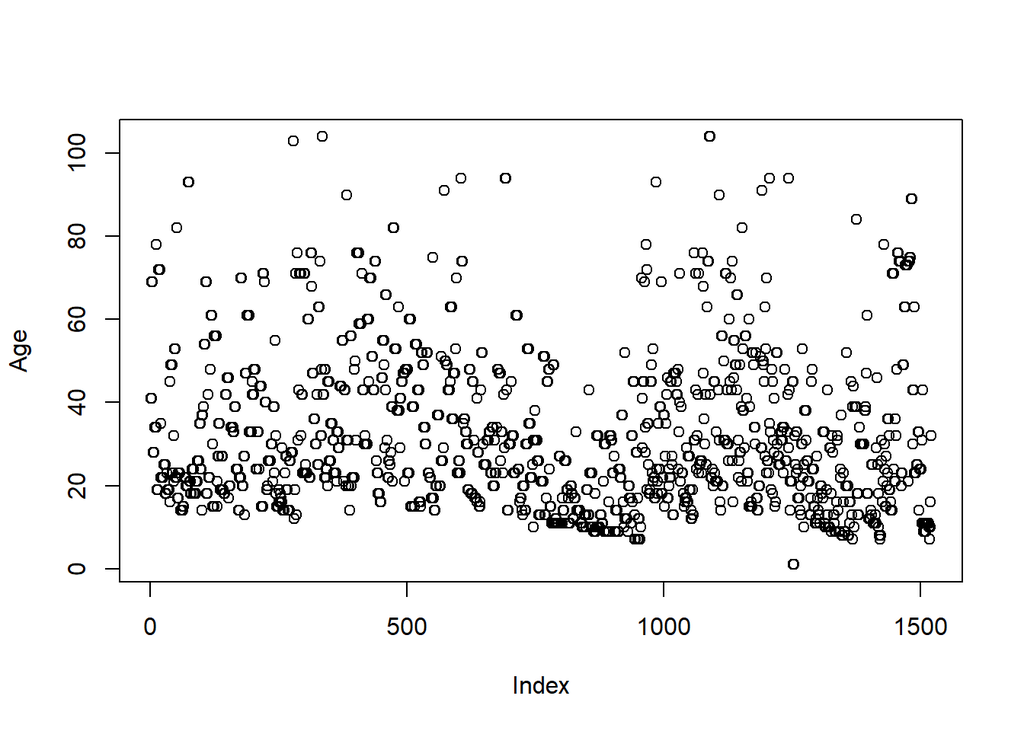

```r
# Plot the age variable
plot(BD$AGE, ylab = "Age")
```

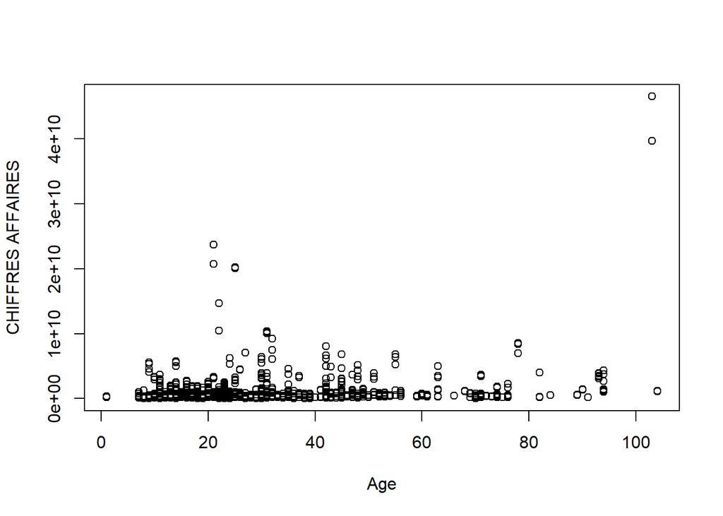

```r
# Save the outlier's index to index_highage
index_highage <- which(BD$AGE > 122)

# Create data set new_data with outlier deleted
new_data <- BD[-index_highage, ]

# Make bivariate scatterplot of age and revenue
plot(BD$AGE, BD$CHIFFRE_AFFAIRES, xlab = "Age", ylab = "CHIFFRES AFFAIRES")
```

[figure not shown]

```r
new <- ggplot(BD, aes(x = factor(`defaut`), fill = REPUTATION))

val = c("lightcyan2", "lightcyan3","lightblue","lightcyan4","cadetblue3","aquamarine","darkblue")
lab = c("Tres bonne","Très bonne","Bonne","Moyenne" ,"Mauvaise")
new + geom_bar(position = "dodge",alpha = 0.75) +
      scale_x_discrete("Defaut") +
      scale_y_continuous("Count") +
      scale_fill_manual("Reputation",values = val,labels = lab)
```

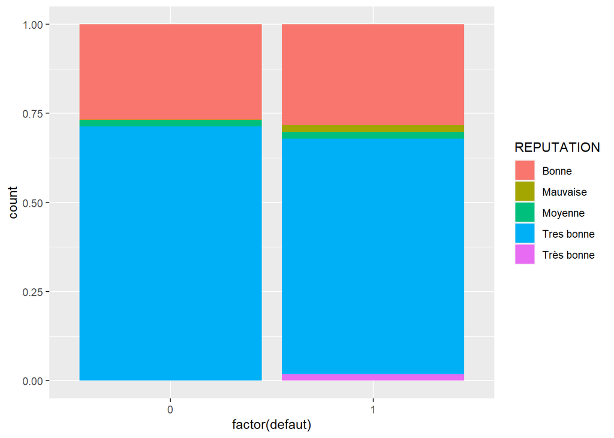

```r
ggplot(BD, aes(x = factor(`defaut`), fill = REPUTATION)) + geom_bar(position = "fill")
```

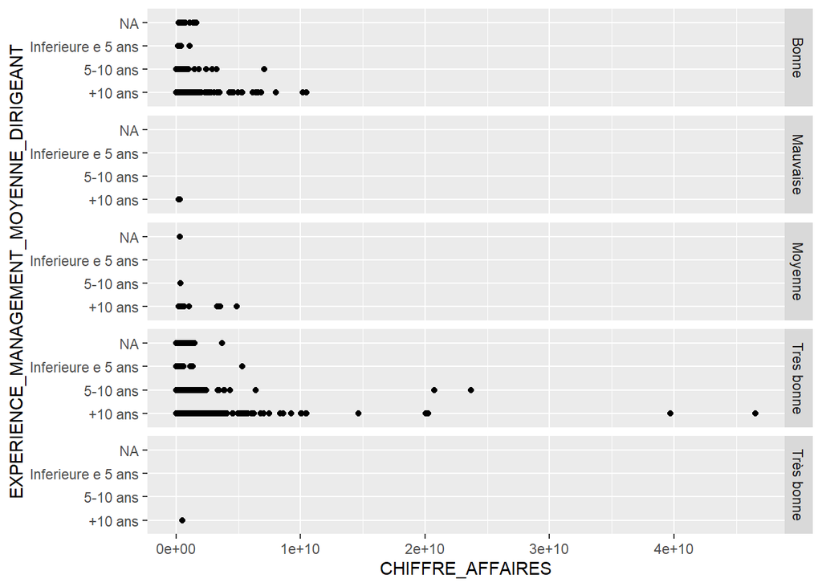

```r
ggplot(BD,aes(x = CHIFFRE_AFFAIRES ,y = EXPERIENCE_MANAGEMENT_MOYENNE_DIRIGEANT)) + geom_point() +
  facet_grid(REPUTATION ~ .)
```

La réputation en ce qui concerne le défaut de remboursement des prêts nous donne peu d’indications, mais la distribution des chiffres d’affaires par rapport au nombre d’années d’expérience managériale de l’entreprise nous indique qu’il y a beaucoup d’entreprises ayant +10 ans d’expérience avec de bons chiffres d’affaires. Ce qui est logique.

Régression logistique et performance du modèle :

En statistique, la régression logistique, ou régression logit, ou modèle logit est un modèle de régression où la variable dépendante (DV) est catégorique.La régression logistique mesure la relation entre la variable dépendante catégorique et une ou plusieurs variables indépendantes en estimant les probabilités à l’aide d’une fonction logistique, qui est la distribution logistique cumulative.

Ainsi, elle traite le même ensemble de problèmes que la régression probit en utilisant des techniques similaires, cette dernière utilisant plutôt une courbe de distribution normale cumulative. De manière équivalente, dans les interprétations des variables latentes de ces deux méthodes, la première suppose une distribution logistique standard des erreurs et la seconde une distribution normale standard des erreurs.

La régression logistique peut être considérée comme un cas particulier du modèle linéaire généralisé et est donc analogue à la régression linéaire. Le modèle de régression logistique, cependant, est basé sur des hypothèses assez différentes (sur la relation entre les variables dépendantes et indépendantes) de celles de la régression linéaire. En particulier, les principales différences de ces deux modèles peuvent être vues dans les deux caractéristiques suivantes de la régression logistique.

Premièrement, la distribution conditionnelle est une distribution de Bernoulli plutôt qu’une distribution gaussienne, car la variable dépendante est binaire. Deuxièmement, les valeurs prédites sont des probabilités et sont donc limitées à (0,1) par la fonction de distribution logistique, car la régression logistique prédit la probabilité de résultats particuliers.

```r
set.seed(123)

library(ROCR, warn.conflicts = FALSE)
index_train <- sample(1:nrow(BD), 2 / 3* nrow(BD))
training_set <- BD[c(index_train), ]
test_set <- BD[-index_train, ]



log_reg_small <- glm(`defaut` ~ REPUTATION + CHIFFRE_AFFAIRES + DETTE_FINANCIERE + EXPERIENCE_MANAGEMENT_MOYENNE_DIRIGEANT,
                     family = "binomial", data = training_set)

summary(log_reg_small)
```

```
##
## Call:
## glm(formula = defaut ~ REPUTATION + CHIFFRE_AFFAIRES + DETTE_FINANCIERE +
##     EXPERIENCE_MANAGEMENT_MOYENNE_DIRIGEANT, family = "binomial",
##     data = training_set)
##
## Deviance Residuals:
##     Min       1Q   Median       3Q      Max
## -0.7035  -0.2809  -0.2654  -0.2290   2.9157
##
## Coefficients:
##                                                             Estimate Std. Error
## (Intercept)                                               -3.122e+00  3.973e-01
## REPUTATIONMauvaise                                        -1.970e+01  3.956e+03
## REPUTATIONMoyenne                                          7.559e-01  1.103e+00
## REPUTATIONTres bonne                                       4.251e-02  4.195e-01
## REPUTATIONTrès bonne                                       2.102e+01  3.956e+03
## CHIFFRE_AFFAIRES                                          -7.299e-10  3.523e-10
## DETTE_FINANCIERE                                           4.586e-10  2.150e-10
## EXPERIENCE_MANAGEMENT_MOYENNE_DIRIGEANT5-10 ans            1.146e-01  4.240e-01
## EXPERIENCE_MANAGEMENT_MOYENNE_DIRIGEANTInferieure e 5 ans -1.402e+01  1.178e+03
##                                                           z value Pr(>|z|)
## (Intercept)                                                -7.857 3.92e-15 ***
## REPUTATIONMauvaise                                         -0.005   0.9960
## REPUTATIONMoyenne                                           0.685   0.4931
## REPUTATIONTres bonne                                        0.101   0.9193
## REPUTATIONTrès bonne                                        0.005   0.9958
## CHIFFRE_AFFAIRES                                           -2.072   0.0383 *
## DETTE_FINANCIERE                                            2.133   0.0329 *
## EXPERIENCE_MANAGEMENT_MOYENNE_DIRIGEANT5-10 ans             0.270   0.7870
## EXPERIENCE_MANAGEMENT_MOYENNE_DIRIGEANTInferieure e 5 ans  -0.012   0.9905
## ---
## Signif. codes:  0 '***' 0.001 '**' 0.01 '*' 0.05 '.' 0.1 ' ' 1
##
## (Dispersion parameter for binomial family taken to be 1)
##
##     Null deviance: 287.86  on 967  degrees of freedom
## Residual deviance: 272.66  on 959  degrees of freedom
##   (46 observations deleted due to missingness)
## AIC: 290.66
##
## Number of Fisher Scoring iterations: 16
```

Il est temps de faire quelques prédictions avec notre modèle et de le tester sur différents paramètres.

```r
predictions_small <- predict(log_reg_small, newdata = test_set,
                              type = "response")

range(predictions_small)
```

```
## [1] NA NA
```

```r
pred_cutoff_15_small <- ifelse(predictions_small > 0.15,1,0)

conf_15_small <- table(test_set$`defaut`,pred_cutoff_15_small)
conf_15_small
```

```
##    pred_cutoff_15_small
##       0   1
##   0 470   1
##   1  16   1
```

```r
accuracy_15_small <- sum(diag(conf_15_small))/sum(conf_15_small)
accuracy_15_small
```

```
## [1] 0.9651639
```

```r
pred_cutoff_20_small <- ifelse(predictions_small > 0.20,1,0)

conf_20_small <- table(test_set$`defaut`,pred_cutoff_20_small)
conf_20_small
```

```
##    pred_cutoff_20_small
##       0
##   0 471
##   1  17
```

```r
accuracy_20_small <- sum(diag(conf_20_small))/sum(conf_20_small)
accuracy_20_small
```

```
## [1] 0.9651639
```